# Statistical Analysis on NYC Weather Data

```python
import pandas as pd
import numpy as np
from matplotlib import pyplot as plt
```

### Import the data as comma separated value (csv) format

```python
nyc_weather = pd.read_csv('nyc_weather.csv')
nycISI = pd.read_csv('nyc_weather.csv') # to be converted to ISI units
nyc_weather.head() # preview
```

|  | Unnamed: 0 | Date | Max.TemperatureF | Mean.TemperatureF | Min.TemperatureF | Max.Dew.PointF | MeanDew.PointF | Min.DewpointF | Max.Humidity | Mean.Humidity | ... | Min.VisibilityMiles | Max.Wind.SpeedMPH | Mean.Wind.SpeedMPH | Max.Gust.SpeedMPH | PrecipitationIn | CloudCover | Events | WindDirDegrees.br... | city | season |
| --- | --- | --- | --- | --- | --- | --- | --- | --- | --- | --- | --- | --- | --- | --- | --- | --- | --- | --- | --- | --- | --- |
| 0 | 1 | 1948-07-01 | 84 | 78.0 | 72 | 71 | 65 | 58 | 93 | 65 | ... | 2.0 | 16 | 8 | NaN | 0.00 | 0.0 | Fog | 264<br /> | New York City (USA) | Summer |
| 1 | 2 | 1948-07-02 | 82 | 72.0 | 63 | 62 | 53 | 49 | 76 | 51 | ... | 10.0 | 16 | 10 | NaN | 0.00 | 0.0 | NaN | 315<br /> | New York City (USA) | Summer |
| 2 | 3 | 1948-07-03 | 78 | 71.0 | 64 | 66 | 58 | 53 | 84 | 62 | ... | 5.0 | 14 | 6 | NaN | 0.00 | 0.0 | NaN | 203<br /> | New York City (USA) | Summer |
| 3 | 4 | 1948-07-04 | 84 | 76.0 | 68 | 68 | 63 | 56 | 90 | 67 | ... | 2.0 | 12 | 5 | NaN | 0.00 | 0.0 | Fog | 198<br /> | New York City (USA) | Summer |
| 4 | 5 | 1948-07-05 | 93 | 82.0 | 70 | 74 | 69 | 65 | 93 | 71 | ... | 3.0 | 18 | 8 | NaN | 0.00 | 0.0 | Fog-Rain-Thunderstorm | 218<br /> | New York City (USA) | Summer |

5 rows × 26 columns

```python
nycISI.columns
```

```
Index(['Unnamed: 0', 'Date', 'Max.TemperatureF', 'Mean.TemperatureF',
       'Min.TemperatureF', 'Max.Dew.PointF', 'MeanDew.PointF', 'Min.DewpointF',
       'Max.Humidity', 'Mean.Humidity', 'Min.Humidity',
       'Max.Sea.Level.PressureIn', 'Mean.Sea.Level.PressureIn',
       'Min.Sea.Level.PressureIn', 'Max.VisibilityMiles',
       'Mean.VisibilityMiles', 'Min.VisibilityMiles', 'Max.Wind.SpeedMPH',
       'Mean.Wind.SpeedMPH', 'Max.Gust.SpeedMPH', 'PrecipitationIn',
       'CloudCover', 'Events', 'WindDirDegrees.br...', 'city', 'season'],
      dtype='object')
```

### Conversion of the units to ISI units in the data frame nycISI

```python
nycISI.rename(columns={'Max.TemperatureF' : 'Max.TemperatureC', 'Mean.TemperatureF' : 'Mean.TemperatureC', 'Min.TemperatureF' : 'Min.TemperatureC'}, inplace = True)
nycISI[['Max.TemperatureC', 'Mean.TemperatureC', 'Min.TemperatureC']] = (nyc_weather[['Max.TemperatureF', 'Mean.TemperatureF', 'Min.TemperatureF']]-32) / 1.8
nycISI.rename(columns={'Max.Dew.PointF' : 'Max.Dew.PointC', 'MeanDew.PointF' : 'Mean.Dew.PointC', 'Min.DewpointF' : 'Min.Dew.PointC'}, inplace = True)
nycISI[['Max.Dew.PointC', 'Mean.Dew.PointC', 'Min.Dew.PointC']] = (nyc_weather[['Max.Dew.PointF', 'MeanDew.PointF', 'Min.DewpointF']]-32) / 1.8
nycISI.rename(columns={'Max.VisibilityMiles':'Max.VisibilityKm', 'Mean.VisibilityMiles' : 'Mean.VisibilityKm', 'Min.VisibilityMiles' : 'Min.VisibilityKm'}, inplace = True)
nycISI[['Max.VisibilityKm', 'Mean.VisibilityKm', 'Min.VisibilityKm']] = (nyc_weather[['Max.VisibilityMiles', 'Mean.VisibilityMiles', 'Min.VisibilityMiles']]) * 1.6
nycISI.rename(columns = {'Max.Wind.SpeedMPH': 'Max.Wind.SpeedKPH', 'Mean.Wind.SpeedMPH': 'Mean.Wind.SpeedKPH'}, inplace = True)
nycISI[['Max.Wind.SpeedKPH', 'Mean.Wind.SpeedKPH']] = nyc_weather[['Max.Wind.SpeedMPH', 'Mean.Wind.SpeedMPH']] * 1.6
```

# Part 1. Simple Statistical Analysis

## What is the distribution of temperature?

```python
## are there any nan values in the mean temperature data?
nycISI['Mean.TemperatureC'].isnull().sum()
```

```
2
```

```python
nycISI['Mean.TemperatureC'].describe()
```

```
count    24558.000000
mean        12.290225
std          9.303510
min        -15.555556
25%          5.000000
50%         12.222222
75%         20.555556
max         33.333333
Name: Mean.TemperatureC, dtype: float64
```

```python
print('The average temperature in NYC from {} to {} is {} C.'.format(nycISI['Date'][0], nycISI['Date'][-1:].values[0], round(nycISI['Mean.TemperatureC'].mean(), 3)))
```

```
The average temperature in NYC from 1948-07-01 to 2015-12-31 is 12.29 C.
```

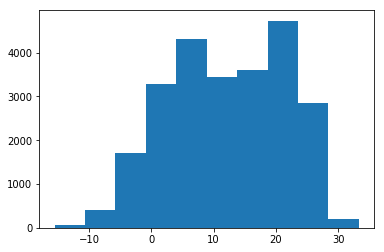

```python
plt.hist(nycISI['Mean.TemperatureC'].fillna(nycISI['Mean.TemperatureC'].mean())) # fillna to replace the nan with the mean temperature to avoid errors
plt.show()
```

### What are the maximums/minimums and when did they happen?

### Max wind speed ever recorded

```python
max_windSpeed = nycISI['Max.Wind.SpeedKPH'].max()
date_maxWindSpeed = nycISI['Date'][nycISI['Max.Wind.SpeedKPH'] == max_windSpeed].values[0]
print('Maximum wind speed ever recorded in NYC since {} is {} KPH which occured on {}.'.format(nycISI['Date'].min(), round(max_windSpeed, 3), date_maxWindSpeed))
```

```
Maximum wind speed ever recorded in NYC since 1948-07-01 is 185.6 KPH which occured on 2014-03-22.
```

### Max temperature ever recorded

```python
max_temp = nycISI['Max.TemperatureC'].max()
date_maxTemp = nycISI['Date'][nycISI['Max.TemperatureC'] == max_temp].values[0]
print('Maximum temperature ever recorded in NYC since {} is {} C which occured on {}.'.format(nycISI['Date'][0], round(max_temp, 3), date_maxTemp  ))
```

```
Maximum temperature ever recorded in NYC since 1948-07-01 is 39.444 C which occured on 2011-07-22.
```

#### The maximum temperature ever recorded is very recent (> 2011). Is this a sign of climate change?

### Min temperature ever recorded

```python
min_temp = nycISI['Min.TemperatureC'].min()
date_minTemp = nycISI['Date'][nycISI['Min.TemperatureC'] == min_temp].values[0]
print('Minimum temperature ever recorded in NYC since {} is {} C which occured on {}.'.format(nycISI['Date'][0], round(min_temp, 3), date_minTemp))
```

```
Minimum temperature ever recorded in NYC since 1948-07-01 is -18.889 C which occured on 1985-01-21.
```

```python
nycISI.head()
```

|  | Unnamed: 0 | Date | Max.TemperatureC | Mean.TemperatureC | Min.TemperatureC | Max.Dew.PointC | Mean.Dew.PointC | Min.Dew.PointC | Max.Humidity | Mean.Humidity | ... | Min.VisibilityKm | Max.Wind.SpeedKPH | Mean.Wind.SpeedKPH | Max.Gust.SpeedMPH | PrecipitationIn | CloudCover | Events | WindDirDegrees.br... | city | season |
| --- | --- | --- | --- | --- | --- | --- | --- | --- | --- | --- | --- | --- | --- | --- | --- | --- | --- | --- | --- | --- | --- |
| 0 | 1 | 1948-07-01 | 28.888889 | 25.555556 | 22.222222 | 21.666667 | 18.333333 | 14.444444 | 93 | 65 | ... | 3.2 | 25.6 | 12.8 | NaN | 0.00 | 0.0 | Fog | 264<br /> | New York City (USA) | Summer |
| 1 | 2 | 1948-07-02 | 27.777778 | 22.222222 | 17.222222 | 16.666667 | 11.666667 | 9.444444 | 76 | 51 | ... | 16.0 | 25.6 | 16.0 | NaN | 0.00 | 0.0 | NaN | 315<br /> | New York City (USA) | Summer |
| 2 | 3 | 1948-07-03 | 25.555556 | 21.666667 | 17.777778 | 18.888889 | 14.444444 | 11.666667 | 84 | 62 | ... | 8.0 | 22.4 | 9.6 | NaN | 0.00 | 0.0 | NaN | 203<br /> | New York City (USA) | Summer |
| 3 | 4 | 1948-07-04 | 28.888889 | 24.444444 | 20.000000 | 20.000000 | 17.222222 | 13.333333 | 90 | 67 | ... | 3.2 | 19.2 | 8.0 | NaN | 0.00 | 0.0 | Fog | 198<br /> | New York City (USA) | Summer |
| 4 | 5 | 1948-07-05 | 33.888889 | 27.777778 | 21.111111 | 23.333333 | 20.555556 | 18.333333 | 93 | 71 | ... | 4.8 | 28.8 | 12.8 | NaN | 0.00 | 0.0 | Fog-Rain-Thunderstorm | 218<br /> | New York City (USA) | Summer |

5 rows × 26 columns

# Part 2. Prediction of Temperature and global warming

### Average daily temperature variation in NYC

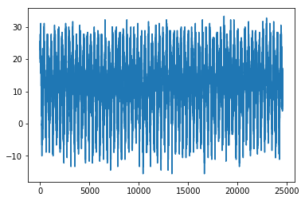

```python
plt.plot(nycISI['Mean.TemperatureC'])
plt.show()
```

### Average yearly temperature variation from 1949 to 2015

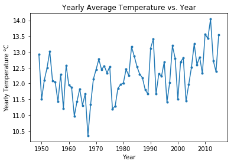

```python
StartYear = int(nycISI['Date'].values[0][0:4]) + 1 # the +1 is to not include the first year (1948) whose data is only partially available
EndYear = int(nycISI['Date'].values[-1][0:4])
nycTemp = pd.DataFrame({'year' : range(StartYear, EndYear + 1)})
nycTemp = nycTemp[['year']]
mean_temp = []
for k in nycTemp['year']:
    is_year_equal_to_k = []
    for date in nycISI['Date']:
        is_year_equal_to_k.append(date.startswith(str(k)))
    mean_temp.append((nycISI['Mean.TemperatureC'][is_year_equal_to_k]).mean())
    is_year_equal_to_k = []
nycTemp['Mean Temp'] = mean_temp
plt.plot(nycTemp['year'], nycTemp['Mean Temp'], '.-')
plt.xlabel('Year')
plt.ylabel('Yearly Temperature \u00b0C')
plt.title('Yearly Average Temperature vs. Year')
plt.show()
```

### Five-year-average temperature average

```
range(0, 67)
```

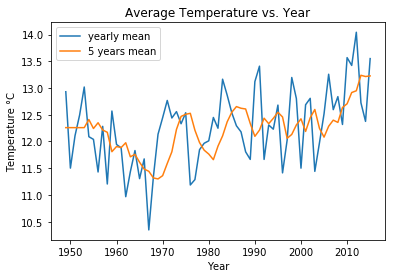

```python
w = 5
mean_w_years_temp = []
start_index = 0
kRange = range(0, len(nycTemp['year']))
print(kRange)
for k in kRange:
    if k >= w :
        start_index = k - w
        end_index = k
    else:
        start_index = 0
        end_index = 4
    mean_w_years_temp.append((nycTemp['Mean Temp'][start_index:end_index]).mean())
nycTemp['5Years Mean Temperature'] = mean_w_years_temp
plt.plot(nycTemp['year'], nycTemp['Mean Temp'], label = 'yearly mean')
plt.plot(nycTemp['year'], nycTemp['5Years Mean Temperature'], label = '5 years mean')
plt.xlabel('Year')
plt.ylabel('Temperature \u00b0C')
plt.legend()
plt.title('Average Temperature vs. Year')
plt.show()
```

```python
print('From {} to {} in NYC the 5-year average temperature has increased by {}\u00b0c! Is this a sign of global warming?'.format(nycTemp['year'].values[0], nycTemp['year'][-1:].values[0], round(nycTemp['5Years Mean Temperature'][-1:].values[0] - nycTemp['5Years Mean Temperature'][0], 2)))
year_max = nycTemp['year'][nycTemp['5Years Mean Temperature'] == nycTemp['5Years Mean Temperature'].max()].values[0]
print('\nThe highest 5-year temperature average from {} to {} in NYC has occured in {}. Is this a sign of global warming?'.format(nycTemp['year'].values[0], nycTemp['year'][-1:].values[0], year_max))
```

```
From 1949 to 2015 in NYC the 5-year average temperature has increased by 0.97°c! Is this a sign of global warming?

The highest 5-year temperature average from 1949 to 2015 in NYC has occured in 2013. Is this a sign of global warming?
```

### Given the chaotic nature of the yearly-average temperature graph, it is does not seem possible to be able to do a regression with time (= year) as the feature. So, we look at the 5 year average which should be less chaotic:

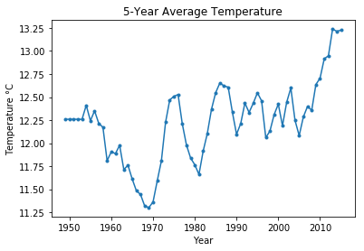

```python
plt.plot(nycTemp['year'], nycTemp['5Years Mean Temperature'],  '.-')
plt.xlabel('Year')
plt.ylabel('Temperature \u00b0C')
plt.title('5-Year Average Temperature')
plt.show()
```

### Still the 5 years average is chaotic, below we look at the 40 years average.

```python
w = 40
mean_w_years_temp = []
start_index = 0
kRange = range(0, len(nycTemp['year']))
print(kRange)
for k in kRange:
    if k >= w :
        start_index = k - w
        end_index = k
    else:
        start_index = 0
        end_index = 4
    mean_w_years_temp.append((nycTemp['Mean Temp'][start_index:end_index]).mean())
nycTemp['40Years Mean Temperature'] = mean_w_years_temp
```

```
range(0, 67)
```

## Global warming?

### As seen in the graph below, the temperature increase on a 40-years average temperature graph is quite clear.

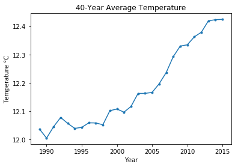

```python
plt.plot(nycTemp['year'][w:], nycTemp['40Years Mean Temperature'][w:],  '.-')
plt.xlabel('Year')
plt.ylabel('Temperature \u00b0C')
plt.title('40-Year Average Temperature')
plt.show()
```

```python
from sklearn.linear_model import LinearRegression
from sklearn.model_selection import TimeSeriesSplit
from sklearn import metrics
```

```python
linreg = LinearRegression()
```

```python
X = nycTemp['year'].values[w:] - nycTemp['year'][w] # number of years from 1989
X = X.reshape(-1, 1)
y = nycTemp['40Years Mean Temperature'].values[w:]
```

```python
type(X)
```

```
numpy.ndarray
```

```python
tscv = TimeSeriesSplit(n_splits=2)
```

```python
for train_index, test_index in tscv.split(X):
    print('Train:', train_index, 'Test:', test_index)
    X_train, X_test = X[train_index], X[test_index]
    y_train, y_test = y[train_index], y[test_index]
```

```
Train: [0 1 2 3 4 5 6 7 8] Test: [ 9 10 11 12 13 14 15 16 17]
Train: [ 0  1  2  3  4  5  6  7  8  9 10 11 12 13 14 15 16 17] Test: [18 19 20 21 22 23 24 25 26]
```

```python
linreg.fit(X_train, y_train)
```

```
LinearRegression(copy_X=True, fit_intercept=True, n_jobs=1, normalize=False)
```

```python
y_pred = linreg.predict(X)
```

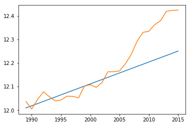

```python
plt.plot(nycTemp['year'].values[w:], y_pred)
plt.plot(nycTemp['year'].values[w:], y)
plt.show()
```

```python
metrics.mean_squared_error(y, y_pred)
```

```
0.0075578485752348388
```

```python
linreg.coef_
```

```
array([ 0.00927467])
```

```python
print('The 40-year-average temperature increases by around {0:.2f}\u00b0 every year!'.format(linreg.coef_[0]))
```

```
The 40-year-average temperature increases by around 0.01° every year!
```

### The linear regression does not give us a good fit, however, the positive slope of the line suggests that the 40-year average temperature increases by around 0.01 degrees every year.

## Degree 2 polynomial regression

```python
t = nycTemp['year'].values[w:] - nycTemp['year'][w] # number of years from 1989
X = []
for k in range(0, len(t)):
    X.append([t[k], t[k]**2])
```

```python
X
```

```
[[0, 0],
 [1, 1],
 [2, 4],
 [3, 9],
 [4, 16],
 [5, 25],
 [6, 36],
 [7, 49],
 [8, 64],
 [9, 81],
 [10, 100],
 [11, 121],
 [12, 144],
 [13, 169],
 [14, 196],
 [15, 225],
 [16, 256],
 [17, 289],
 [18, 324],
 [19, 361],
 [20, 400],
 [21, 441],
 [22, 484],
 [23, 529],
 [24, 576],
 [25, 625],
 [26, 676]]
```

```python
for train_index, test_index in tscv.split(X):
    print('Train:', train_index, 'Test:', test_index)
    X_train, X_test = X[train_index[0]:train_index[-1]+1], X[test_index[0]:test_index[-1]+1]
    y_train, y_test = y[train_index], y[test_index]
```

```
Train: [0 1 2 3 4 5 6 7 8] Test: [ 9 10 11 12 13 14 15 16 17]
Train: [ 0  1  2  3  4  5  6  7  8  9 10 11 12 13 14 15 16 17] Test: [18 19 20 21 22 23 24 25 26]
```

```python
linreg2 = LinearRegression()
linreg2.fit(X_train, y_train)
```

```
LinearRegression(copy_X=True, fit_intercept=True, n_jobs=1, normalize=False)
```

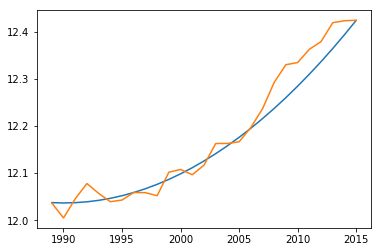

```python
y_pred = linreg2.predict(X)
plt = plt
plt.plot(nycTemp['year'].values[w:], y_pred)
plt.plot(nycTemp['year'].values[w:], y)
plt.show()
```

```python
metrics.mean_squared_error(y, y_pred)
```

```
0.00089244697698673953
```

```python
# in 20 years: 2015-1989
linreg2.predict([[46, 46**2]])
```

```
array([ 13.29193079])
```